How to create applications  
using Shiny

ISGlobal

Barcelona, February 13-14th 2018

Bloque III: Logic of Shiny

### Outline

**Part III: Logic of Shiny**

- How Shiny works
- Isolate
- Reactive objects
- Upload data
- Download files
- Validate inputs
- Rendering elements

How Shiny works

### UI & Server sections

**UI**

- Where the elements and form structure is specified.
- The commands to create elements must be separated by commas.
- Do not write `input$elem`.  
  You can only refer to input elements values thru `conditionalPanel`.

```r
fluidPage(
  textInput(...),
  conditionalPanel("input.help",
        ...
  ),
  tabsetPanel(
    tabPanel(...),
    tabPanel(...)
  ),
  plotOutput(...)
)
```

**Server**

Where the computations are performed (tables, plots, etc). It can contain

- UI code using **`renderUI`**:

```r
function(input, output){
  output$elementoUI <- renderUI(
    sliderInput("alias","label", 0, input$n, 0)
  )
}
```

- objects that are re-computed when necessary and used by other functions inside server (**`reactive`**):

```r
function(input, output){
  dat <- reactive(...)
  output$plot <- renderPlot(
    hist(dat())
  )
  output$summ <- renderPrint(
    summary(dat())
  )
}
```

- nothing.

```r
function(input, output){}
```

### Fils structure

**Separated files**

- Mandatory files
  - **`ui.R`**: file with UI section code.
  - **`server.R`**: file with Server section code.
- Optional files
  - **`global.R`**: file where required packages are loaded, data read, objects and functions created, etc. Its code is executed once the app is iniciated.
  - **`www`**: folder with images, CSS code files,…

**Single file**

- Mandatory files
  - **`app.R`**: with UI and Server code, and other code that would be placed in “global.R” file.
- Optional files
  - **`www`**: folder with images, CSS code files,…

### Pipeline

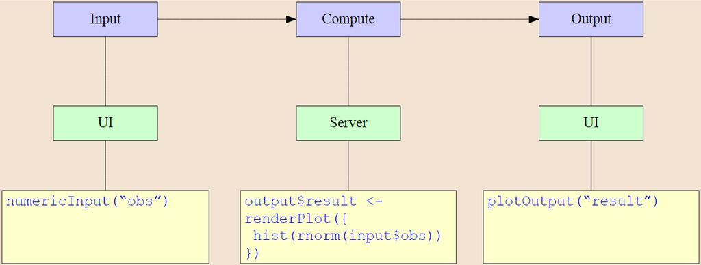

- **Reactivity**: creating and upating elements in **input** and **output** lists.
- **input** and **output** lists are the arguments in the function defined in **Server** section.

### Translationof an R function to a Shiny app

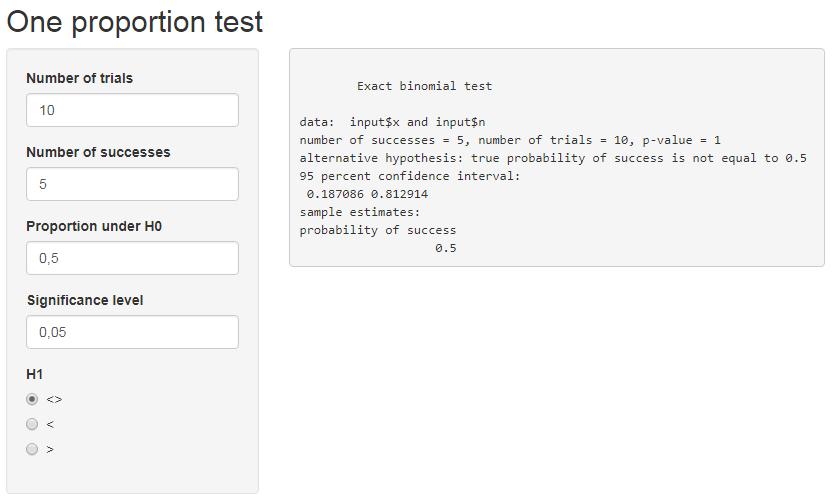

**Inputs:**

- number of trials,
- number of successes,
- proportion under H0,
- significance level,
- H1 direction (one-sided, two-sided).

**Outputs:**

- binomial test result.

```r
ui <- fluidPage(

  titlePanel("One proportion test"),

  sidebarLayout(
    sidebarPanel(
      numericInput("n", "Number of trials", 10),
      numericInput("x", "Number of successes", 5),
      numericInput("p0", "Proportion under H0", 0.5),
      numericInput("alpha", "Significance level", value = 0.05),
      radioButtons("side", "H1", c("<>"=1, "<"=2, ">"=3), 1)
    ),
    mainPanel(
      verbatimTextOutput("result")
    )
  )
)

server <- function(input, output) {

  output$result <- renderPrint({
    binom.test(input$x,
               input$n,
               p = input$p0,
               alt = switch(input$side, '1'="two.sided", '2'="less",'3'="greater"),
               conf.level = 1-input$alpha)
 })

}

shinyApp(ui = ui, server = server)
```

Isolate

### Reactivity control: Isolate

- By default, every time an input element is changed or updated, all instruction inside a “block” or “blocks” in Server section where this or these elements are called (`renderPrint`, `renderTable`, `reactive`, …) are executed.
- If you don't want all these instructions be executed, or results be updated, untill modify all desired inputs, you must specify it. -> **`isolate`** function.

```r
server <- funcion(input, ouput){

  output$foo <- renderXXX({

    input$elem1

    isolate({
      ....
    })

  })
}
```

### Example: One proportion test

Let's recover the previous example. Now it is desired that results don't be updated until the **compute** button is pressed.

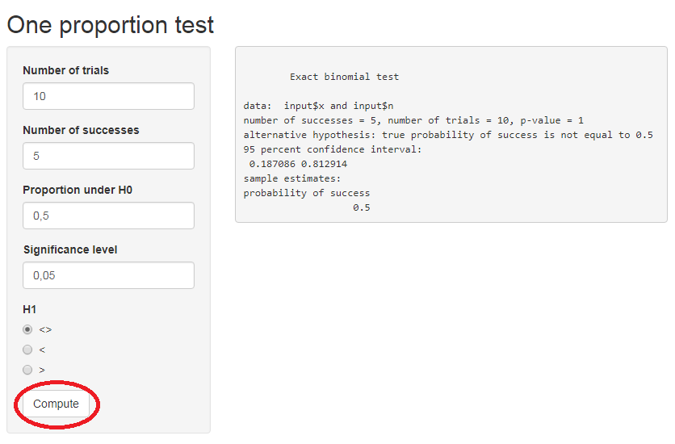

```r
ui <- fluidPage(
  titlePanel("One proportion test"),
  sidebarLayout(
    sidebarPanel(
      numericInput("n", "Number of trials", 10),
      numericInput("x", "Number of successes", 5),
      numericInput("p0", "Proportion under H0", 0.5),
      numericInput("alpha", "Significance level", value = 0.05),
      radioButtons("side", "H1", c("<>"=1, "<"=2, ">"=3), 1),
      actionButton("compute", "Compute")
    ),
    mainPanel(
      verbatimTextOutput("result")
    )
  )
)

server <- function(input, output) {

  output$result <- renderPrint({
    if (input$compute==0) return(invisible(NULL))
    isolate({
      binom.test(input$x,
                 input$n,
                 p = input$p0,
                 alt = switch(input$side, '1'="two.sided", '2'="less",'3'="greater"),
                 conf.level = 1-input$alpha)
    })
 })

}

shinyApp(ui = ui, server = server)
```

Reactive objects

### Reactive objects

- In Shiny, objects are recomputed when some input values are changed by the user.
- At the same time, these input elements may be involved in the computation of several elements of **output** list.
- Recomputing them every time may be inefficient. For example, when reading a huge data base or solving complex algorithms.
- The reactive object is created by the **`reactive`** function.

### Example: iris data to perform a summary and a plot.

```r
function(input, output) {

  dat <- reactive({
    if (input$specie == 'All')
      return(iris)
    else
      return(subset(iris, Species == input$specie))
  })

  output$summary <- renderPrint(summary(dat()))

  output$plot <- renderPlot(pairs(dat()[,-5]))

}
```

**Note:** The object `dat` is **not** a data.frame but a function, `dat()`. It is only updated when needed.

**Exercise**: write the UI section with the minimum required input elements

Upload data

### Upload data

- Use **`fileInput`** function in **UI** section.
- The input element defined with **`fileInput`** contains the file name, among other file properties.
- The proper **R** function will be used to read the file in **Server** section:  
  `spss.get`, `read.table`, `read.xls`, `xlsx`, etc.
- It is suggested to read the data set as a reactive object with the **`reactive`** function.

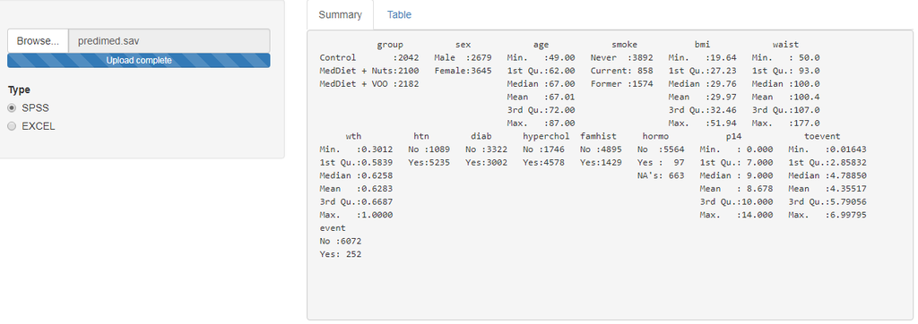

```r
library(Hmisc) # read SPSS
library(xlsx) # read Excel

ui <- fluidPage(
  sidebarLayout(
    sidebarPanel(
      fileInput("files", ""),
      radioButtons("datatype", "Type", c("SPSS","EXCEL"))
    ),
    mainPanel(
      tabsetPanel(
        tabPanel("Summary", verbatimTextOutput("sum")),
        tabPanel("Table", tableOutput("tab"))
      )
    )
  )
)

server <- function(input, output) {
  dd<-reactive({
    inFile<-input$files
    if (is.null(inFile)) return(invisible(NULL))
    if (input$datatype=='EXCEL')
      return(read.xlsx(inFile$datapath,1))
    if (input$datatype=='SPSS')
      return(spss.get(inFile$datapath))
  })
  output$sum <- renderPrint(summary(dd()))
  output$tab <- renderTable(head(dd()))
}

shinyApp(ui = ui, server = server)
```

Download files

### Download files

**From the Server section**

- Use the **`downloadHandler`** function to create the element of the **output** list.
- **`downloadHandler`** has two arguments:
  - **`filename`**: function without any argument that returns the filename.
  - **`content`**: function that creats and save the plot (or the file in general) as the file name defined in its input.

**From the UI section**

- In the **UI** section use the **`downloadButton`** widget.

### Example 1: download a plot

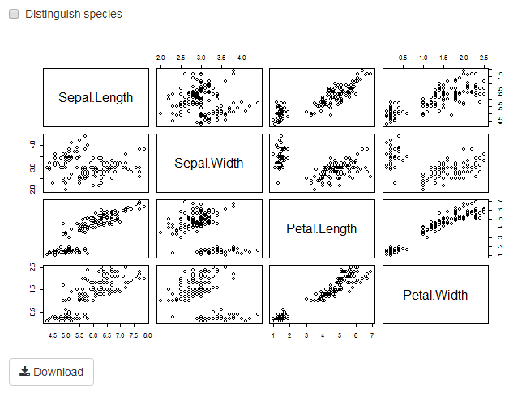

```r
ui <- fluidPage(
  checkboxInput("group", "Distinguish species"),
  plotOutput("result"),
  downloadButton('down', 'Download')
)

server <- function(input, output) {
  output$result <- renderPlot(
    if (input$group)
      pairs(iris[,-5],col=iris[,5])
    else
      pairs(iris[,-5])
  )
  output$down <- downloadHandler(
    filename = function() "figure.pdf",
    content = function(ff) {
      pdf(ff)
      if (input$group)
        pairs(iris[,-5],col=iris[,5])
      else
        pairs(iris[,-5])
      dev.off()
    }
  )
}

shinyApp(ui = ui, server = server)
```

### Example 2: download a data table

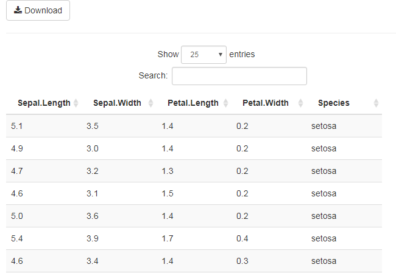

```r
ui <- fluidPage(
  downloadButton('down', 'Download'),
  hr(),
  dataTableOutput("result")
)

server <- function(input, output) {
  output$result <- renderDataTable(iris)
  output$down <- downloadHandler(
    filename = function(){
      "iris.csv"
    },
    content = function(ff){
      write.table(iris, file=ff,
                  sep=";", row.names=FALSE)
    }
  )
}

shinyApp(ui = ui, server = server)
```

**Note:** The app must be launched from a navigator (Chome, Firefox, …). From RStudio viewer only pdf file can be downloaded.

Validate inputs

### Validate inputs

- Sometimes the output (plot, table or text) need of some valid input values.
- Under the user point of view it is useful to recieve a message to know what happens if he or she has introduced wrong parameters.
- Use **`validate`** in conjuntion to **`need`** function
- This text is printed even when a plot or table is expected.
- First argument of `need` is an expression the input element to be checked.
- If the expression is FALSE, NULL, empty or return an error, a message placed as the second argument is displayed in the output.

### Validate inputs

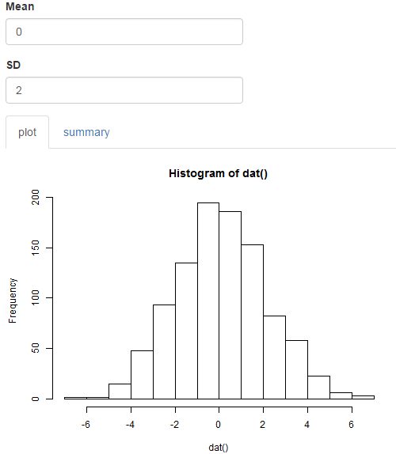

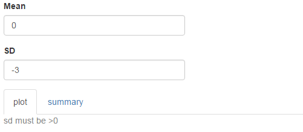

```r
ui <- fluidPage(
  numericInput("mu","Mean",0),
  numericInput("sd","SD",1),
  tabsetPanel(
    tabPanel("plot", plotOutput("plot")),
    tabPanel("summary", verbatimTextOutput("summ"))
  )
)

server <- function(input, output){

  dat <- reactive({

    validate(
      need(input$sd>0,"sd must be >0")
    )

    rnorm(1000, input$mu, input$sd)
  })

  output$plot <- renderPlot(hist(dat()))
  output$summ <- renderPrint(summary(dat()))

}

shinyApp(ui, server)
```

Rendering input elements  
`uiOutput` / `renderUI`

### Rendering elements

- Up to this point, we have seen how to hide or show input elements in the form depending on the value of other input elements by using `conditionalPanel` function.
- But often we want to modify some apects or properties of input elements according to other input element value.
- To do so, there exists **`renderUI`, `uiOutput`** functions to render input elements in a very powerful and flexible way.

### Example. Selecting variables from a data base

- Firstly, the user must choose the data base from (regicor, predimed or SNPs) available from `compareGroups` package.
- Once the data set is chosen, a list containing the variables must appaer.
- The user, then choose which variables are summarized.
- Note that the **items** (`choices` argument) of `selectInput` varies according on the chosen data base.

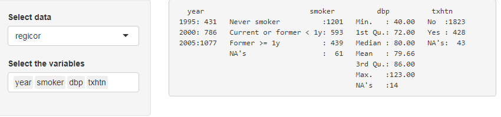

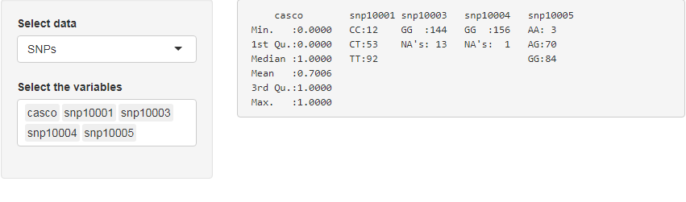

```r
library(compareGroups); data(regicor);data(predimed);data(SNPs)

ui <- fluidPage(
  sidebarLayout(
    sidebarPanel(
      selectInput("data", "Select data", c("regicor", "predimed", "SNPs")),
      uiOutput("listvars")
    ),
    mainPanel(verbatimTextOutput("result"))
  )
)

server <- function(input, output) {

  dat <- reactive(get(input$data))

  output$result <- renderPrint({
    summary(dat()[input$vars])
  })

  output$listvars <- renderUI({
    vars <- names(dat())
    selectInput("vars", "Select the variables", names(dat()), multiple=TRUE)
  })

}

shinyApp(ui = ui, server = server)
```

**Exercise:** Modify the code using `conditionalPanel` function

### Example 2: Password

The app must be visible only if the password is correct.

**Using `conditionalPanel`**

```r
ui <- fluidPage(
  passwordInput("pass","pass"),
  conditionalPanel(
    condition = "input.pass=='123'",
    numericInput("age", "Age", 30),
    textInput("name", "Name", "")
  )
)

server <- function(input, output) {}

shinyApp(ui = ui, server = server)
```

**Problem**: Launch the app from a web browser and click the right side mouse button to see the “source code” and you will see the password.

**Password as an object/variable**

```r
pass<-'123'

ui <- fluidPage(
  passwordInput("pass","pass"),
  conditionalPanel(
    condition = "input.pass==pass",
    numericInput("age", "Age", 30),
    textInput("name", "Name", "")
  )
)

server <- function(input, output) {}

shinyApp(ui = ui, server = server)
```

**Problem:** It doesn't work because no objects or variables can be passed thru `conditionalPanel` condition.

**Using renderUI y uiOutput**

```r
pass<-'123'

ui <- fluidPage(
  passwordInput("pass","pass"),
  uiOutput("result")
)

server <- function(input, output) {
  output$result <- renderUI({
    if (input$pass != pass) return(invisible(NULL))
    tagList(
    numericInput("age", "Age", 30),
    textInput("name", "Name", "")
    )
  })
}

shinyApp(ui = ui, server = server)
```

**It works!!!**

### Source code (browser)

**Using conditionalPanel**

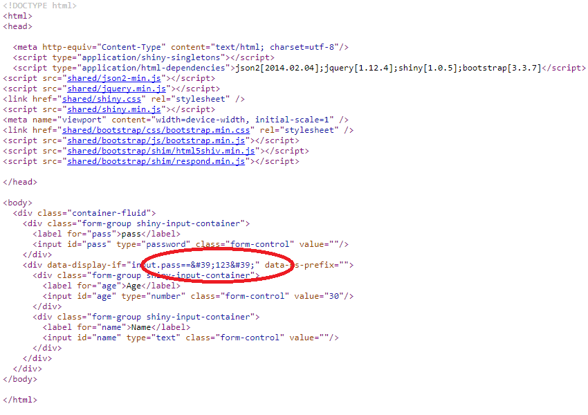

**Using `renderUI` y `uiOutput`**

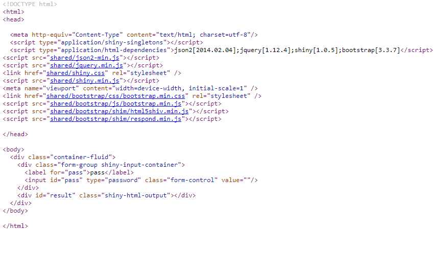

Exercise

**Create an app that:**

1. loads a data base in SPSS.
2. the user choose the variables (one or more).
3. displays a summary of chosen variables.
4. download all variables of the data base in semicolon separated variables csv format.

The app must be visible only when the user enter the correct password (e.g. “123”), which is verified after pressing a button.

**Advanced:** Load an excel file

- The user must have the chance of selecting the sheet
- list of available sheets

`names(getSheets(loadWorkbook(input$file$datapath)))`

### SPSS

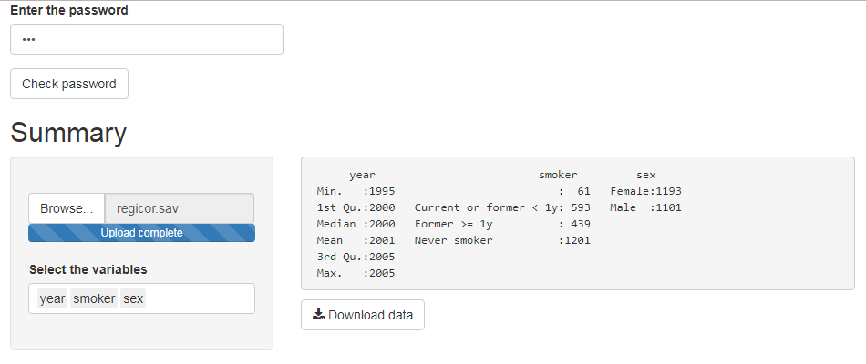

### Excel

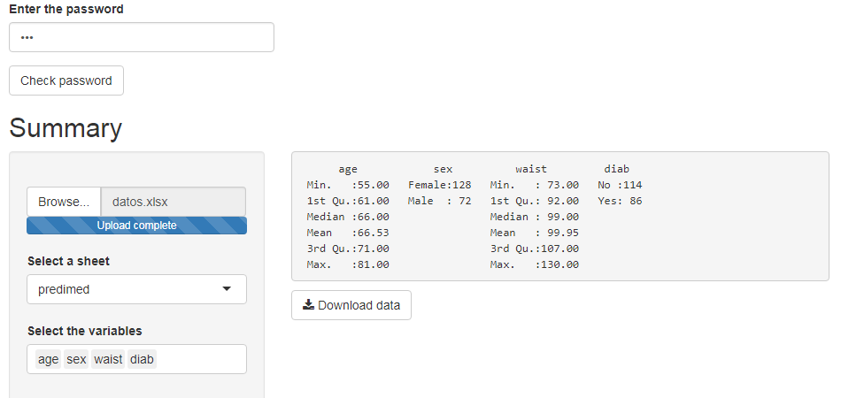